# Klasyfikacja jakości portugalskiego wina

Autor

Weronika Poniedziałek

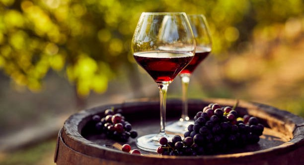

## 1 Wstęp

Wino od wieków zajmuje ważne miejsce w kulturze, kuchni i gospodarce wielu krajów, w tym Portugalii – znanej z unikalnych szczepów winorośli i różnorodnych tradycji winiarskich. Jedną z charakterystycznych odmian produkowanych w tym regionie jest *Vinho Verde*, które wbrew nazwie występuje także w wersji czerwonej. Jakość wina jest pojęciem złożonym i subiektywnym, jednak w przemyśle winiarskim podejmuje się liczne próby jej oceny na podstawie mierzalnych cech chemicznych i fizykochemicznych trunku.

### 1.1 Cel projektu

Celem projektu jest opracowanie modelu predykcyjnego, który na podstawie cech fizykochemicznych wina będzie w stanie ocenić jego jakość. Zadanie to ma charakter problemu **klasyfikacyjnego z uporządkowanymi klasami**, w którym model uczy się przypisywać próbkom ocenę jakościową w skali od 0 do 10.

## 2 Zbiór danych

|  | fixed.acidity | volatile.acidity | citric.acid | residual.sugar | chlorides | free.sulfur.dioxide | total.sulfur.dioxide | density | pH | sulphates | alcohol | quality | Id |
| --- | --- | --- | --- | --- | --- | --- | --- | --- | --- | --- | --- | --- | --- |
| 1 | 7.4 | 0.7 | 0 | 1.9 | 0.076 | 11 | 34 | 0.9978 | 3.51 | 0.56 | 9.4 | 5 | 0 |
| 2 | 7.8 | 0.88 | 0 | 2.6 | 0.098 | 25 | 67 | 0.9968 | 3.2 | 0.68 | 9.8 | 5 | 1 |
| 3 | 7.8 | 0.76 | 0.04 | 2.3 | 0.092 | 15 | 54 | 0.997 | 3.26 | 0.65 | 9.8 | 5 | 2 |
| 4 | 11.2 | 0.28 | 0.56 | 1.9 | 0.075 | 17 | 60 | 0.998 | 3.16 | 0.58 | 9.8 | 6 | 3 |
| 5 | 7.4 | 0.7 | 0 | 1.9 | 0.076 | 11 | 34 | 0.9978 | 3.51 | 0.56 | 9.4 | 5 | 4 |
| 6 | 7.4 | 0.66 | 0 | 1.8 | 0.075 | 13 | 40 | 0.9978 | 3.51 | 0.56 | 9.4 | 5 | 5 |
| 7 | 7.9 | 0.6 | 0.06 | 1.6 | 0.069 | 15 | 59 | 0.9964 | 3.3 | 0.46 | 9.4 | 5 | 6 |
| 8 | 7.3 | 0.65 | 0 | 1.2 | 0.065 | 15 | 21 | 0.9946 | 3.39 | 0.47 | 10 | 7 | 7 |
| 9 | 7.8 | 0.58 | 0.02 | 2 | 0.073 | 9 | 18 | 0.9968 | 3.36 | 0.57 | 9.5 | 7 | 8 |
| 10 | 6.7 | 0.58 | 0.08 | 1.8 | 0.097 | 15 | 65 | 0.9959 | 3.28 | 0.54 | 9.2 | 5 | 10 |

[output cut: 1133 more lines]

### 2.1 Opis zbioru danych

Źródło: https://www.kaggle.com/datasets/yasserh/wine-quality-dataset

W projekcie wykorzystałam rzeczywisty zbiór danych dotyczący czerwonych win typu Vinho Verde, zawierający informacje o składzie chemicznym próbek oraz przypisanych im ocenach jakości. Każda próbka została opisana za pomocą kilkunastu zmiennych, takich jak poziom kwasowości, zawartość cukru resztkowego, alkoholu czy siarczynów.

Moje dane składają się z 1143 próbek.

Zmienne wejściowe są na podstawie testów fizykochemicznych natomiast zmienna wyjściowa (quality) jest na podstawie danych sensorycznych.

Zmienne i ich opis

| Nazwa_zmiennej | Polska_nazwa | Opis |
| --- | --- | --- |
| fixed.acidity | kwasowość stała | Stałe kwasy obecne w winie (np. winowy, cytrynowy) |
| volatile.acidity | kwasowość lotna | Lotne kwasy, głównie octowy – wpływ na zapach |
| citric.acid | kwas cytrynowy | Naturalny kwas – świeżość i owocowy smak |
| residual.sugar | cukier resztkowy | Ilość cukru pozostałego po fermentacji |
| chlorides | chlorki | Zawartość chlorków (np. NaCl) |
| free.sulfur.dioxide | wolny dwutlenek siarki | Część SO₂ działająca jako konserwant |
| total.sulfur.dioxide | całkowity dwutlenek siarki | Całkowita ilość SO₂ – wolna i związana |
| density | gęstość | Gęstość – zależna od cukru i alkoholu |
| pH | pH | Miara kwasowości (niższe pH = większa kwasowość) |
| sulphates | siarczany | Naturalne konserwanty i stabilizatory |
| alcohol | alkohol | Zawartość alkoholu w winie (w %) |
| quality | jakość (zmienna docelowa) | Ocena jakości wina (od 0 - 10) |
| Id | identyfikator | Unikalny numer próbki |

### 2.2 Braki danych

W oryginalnym zbiorze z Kaggle nie występują braki danych, jednakże na potrzeby projektu losowo dodałam braki danych, które prezentują się w następujący sposób:

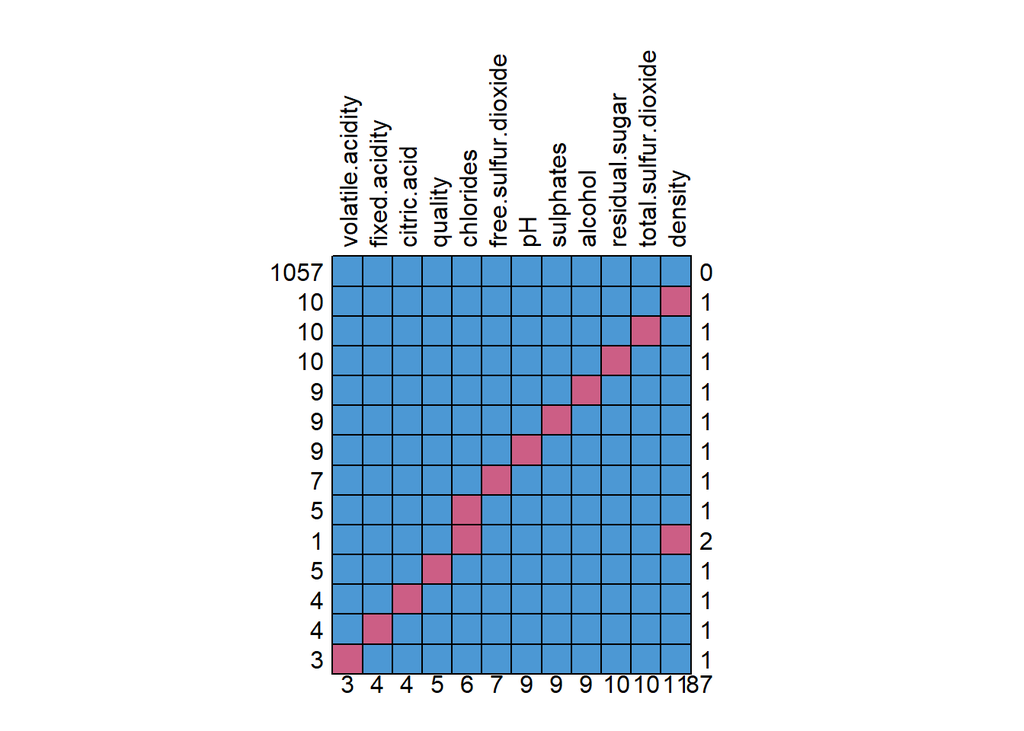

```
       fixed.acidity     volatile.acidity          citric.acid
                   4                    3                    4
      residual.sugar            chlorides  free.sulfur.dioxide
                  10                    6                    7
total.sulfur.dioxide              density                   pH
                  10                   11                    9
           sulphates              alcohol              quality
                   9                    9                    5
```

Przechodzę więc do czyszczenia braków danych.

```
 /\     /\
{  `---'  }
{  O   O  }
==>  V <==  No need for mice. This data set is completely observed.
 \  \|/  /
  `-----'
```

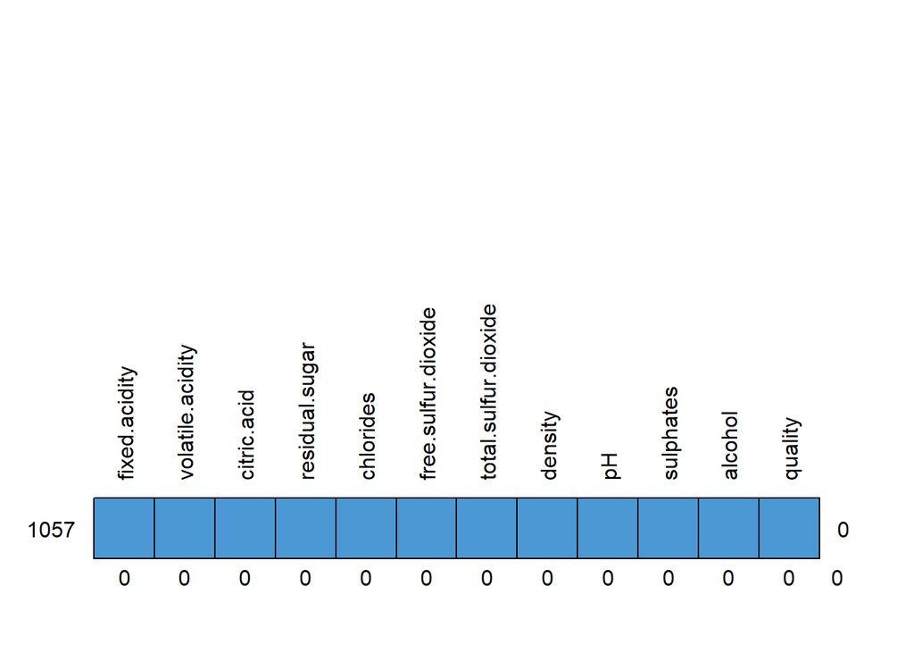

Braki danych zostały usunięte, więc teraz nie występują w zbiorze.

## 3 Analiza zbioru danych

Zanim przystąpimy do budowy modeli, przyjrzymy się bliżej danym. Sprawdzimy m.in. jak wygląda rozkład ocen jakości wina oraz jakie zależności występują między zmiennymi. Taka analiza pozwoli nam lepiej zrozumieć dane i przygotować je do dalszych etapów pracy.

### 3.1 **Procentowy rozkład zmiennej `quality`**

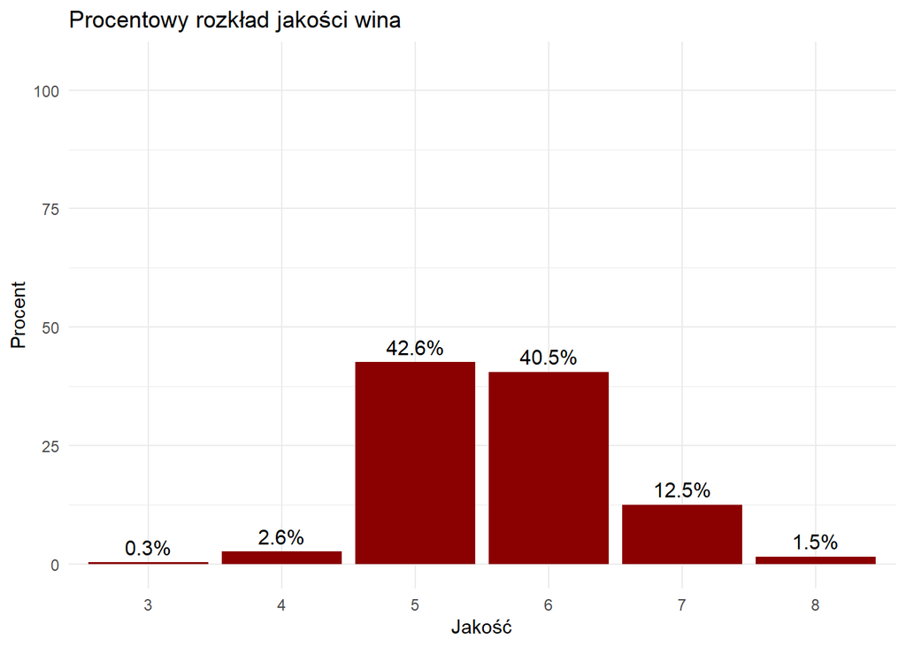

Na podstawie wykresu możemy zauważyć, że zmienna docelowa `quality` jest mocno **niezbalansowana**. Większość obserwacji – **42,6%** oraz **40,5%** – dotyczą win średniej jakości, natomiast pozostałe stanowią wina słabej jakości (3-4) i wina dobrej jakości (7-8). Taka dysproporcja klas może mieć istotny wpływ na skuteczność modeli klasyfikacyjnych i wymaga odpowiednich technik balansowania danych, takich jak np. oversampling.

### 3.2 Rozkład zmiennych numerycznych

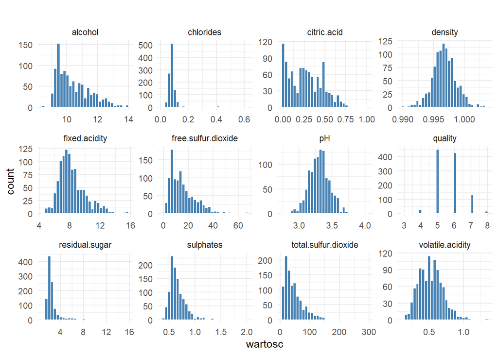

### 3.3 Zmienne względem jakości wina

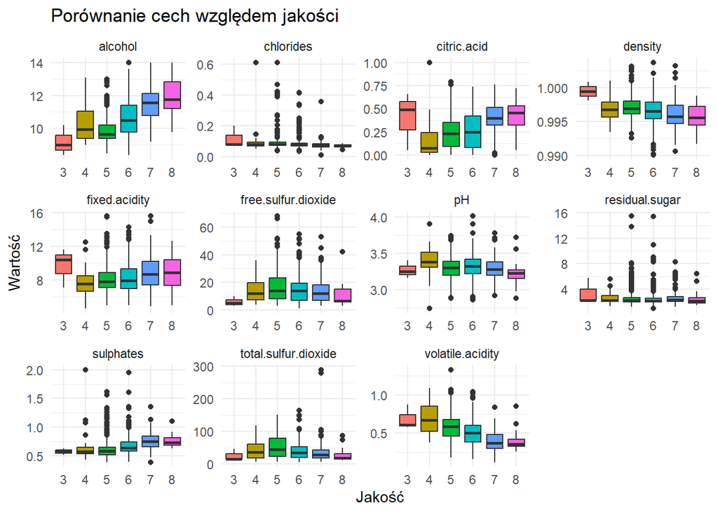

- **Alkohol**

  Wyraźnie zauważalna jest **dodatnia zależność** między zawartością alkoholu a jakością wina. Wina ocenione wyżej (7–8) charakteryzują się wyższym poziomem alkoholu niż wina słabsze (3–5).
- **Lotna kwasowość (`volatile.acidity`)**  
  Im wyższa jakość, tym **niższa zawartość lotnej kwasowości**. Wysokie stężenie kwasu octowego wpływa negatywnie na zapach i smak wina, stąd taki wynik.
- **Kwas cytrynowy (`citric.acid`)**  
  Wysokiej jakości wina wykazują wyższy poziom kwasu cytrynowego, ponieważ nadaje im świeżości i przyjemniejszego profilu smakowego.
- **Siarczany (`sulphates`)**  
  Większa ilość siarczanów towarzyszy wyższej jakości wina.
- **Chlorki i gęstość (`density)`**  
  W tych przypadkach nie widać jednoznacznych zależności – ich wpływ na jakość wydaje się niewielki.
- **Cukier resztkowy (`residual.sugar`)**  
  Brak wyraźnej tendencji – zawartość cukru jest **wysoka** w winach o ocenie 3, ale niekoniecznie powiązana z wysoką oceną.
- **pH**  
  Zmiany wartości pH są delikatne – nie ma dużych różnic pomiędzy klasami jakości.
- **Dwutlenek siarki (`free.sulfur.dioxide`, `total.sulfur.dioxide`)**  
  Nie widać jednoznacznych zależności, ale największa zmienność występuje w średnich klasach jakości wina.

Dodatkowo w zbiorze występuje **duża liczba wartości odstających**, szczególnie w zmiennych związanych z dwutlenkiem siarki, chlorkami oraz cukrem resztkowym. Wartości odstające zidentyfikuję w dalszej części projektu na podstawie reguły IQR i wizualizacji boxplot, aby zobaczyć czy są to rzadkie, lecz rzeczywiste próbki wina czy wartości, które wymagają usunięcia bądź transformacji.

### 3.4 Korelacja zmiennych

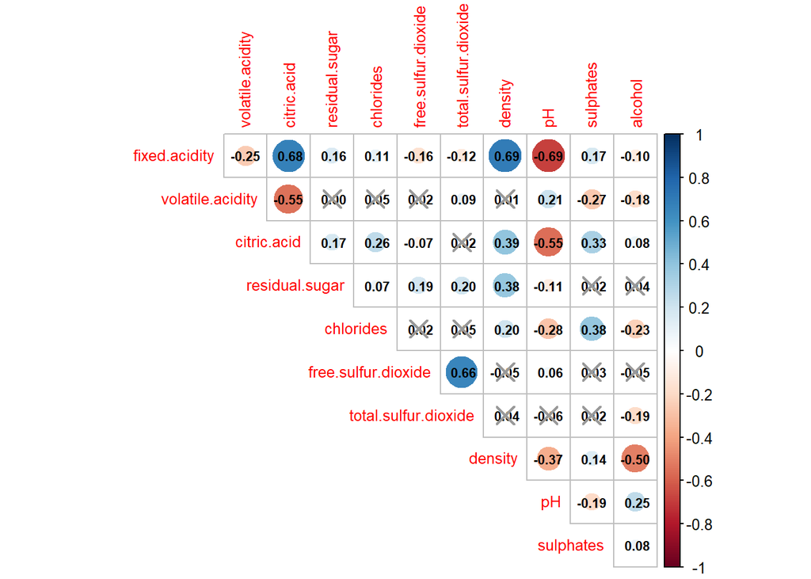

### 3.5 Korelacje zmiennych ze zmienną docelową `quality`

Korelacje zmiennych z jakością wina

|  | Zmienna | Korelacja_z_jakością |
| --- | --- | --- |
| alcohol | alcohol | 0.50 |
| sulphates | sulphates | 0.25 |
| citric.acid | citric.acid | 0.23 |
| fixed.acidity | fixed.acidity | 0.12 |
| residual.sugar | residual.sugar | 0.02 |
| pH | pH | -0.04 |
| free.sulfur.dioxide | free.sulfur.dioxide | -0.07 |
| chlorides | chlorides | -0.13 |
| density | density | -0.18 |
| total.sulfur.dioxide | total.sulfur.dioxide | -0.19 |
| volatile.acidity | volatile.acidity | -0.39 |

Zmienna `alcohol` wykazuje najsilniejszą dodatnią korelację z jakością wina (0.50), co wskazuje na to, że wyższa zawartość alkoholu może być postrzegana jako cecha pozytywna.

Natomiast `volatile.acidity` ma największą ujemną korelacje, co może oznaczać, że nadmiar kwasów lotnych obniżają jakość sensoryczną wina. Chociaż same korelacje nie są bardzo silne, wskazują na potencjalnie istotne predyktory w dalszym modelowaniu.

## 4 Metody analizy (bez tuningu)

### 4.1 **Regresja logistyczna (Logistic Regression)**

Regresja logistyczna to liniowy model klasyfikacyjny, który estymuje prawdopodobieństwo przynależności do jednej z dwóch klas. Jest łatwa do interpretacji i często używana jako punkt odniesienia.

### 4.2 **Drzewo decyzyjne (Decision Tree)**

Model oparty na strukturze drzewa, który dokonuje podziałów zbioru danych na podstawie wartości predyktorów. Łatwy do interpretacji i wizualizacji, choć podatny na przeuczenie (overfitting).

### 4.3 **Las losowy (Random Forest)**

To model składający się z wielu drzew decyzyjnych, budowanych na losowych podzbiorach danych i zmiennych. Dzięki uśrednianiu wyników poszczególnych drzew model ten uzyskuje wysoką stabilość i dokładność, a także zmniejsza ryzyko przeuczenia. Jest to jeden z najczęściej stosowanych modeli klasyfikacyjnych.

### 4.4 **XGBoost (Extreme Gradient Boosting)**

Zaawansowany model oparty na boostingowaniu drzew decyzyjnych. Buduje kolejne drzewa na podstawie błędów poprzednich. Jest bardzo skuteczny, zwłaszcza przy dużych i złożonych zbiorach danych, ale mniej interpretowalny niż prostsze modele.

### 4.5 Naive Bayes

Model probabilistyczny bazujący na twierdzeniu Bayesa i założeniu niezależności między predyktorami. Mimo swojej prostoty, często daje zaskakująco dobre wyniki w klasyfikacji, szczególnie przy dużych zbiorach danych i niezrównoważonych klasach.

### 4.6 SVM

Algorytm klasyfikacyjny, który szuka optymalnej granicy decyzyjnej (hiperpłaszczyzny), maksymalizującej margines między klasami. Dzięki możliwości zastosowania funkcji jądra (kernel), model ten dobrze radzi sobie również z danymi nieliniowo separowalnymi. Charakteryzuje się wysoką skutecznością w przypadku danych o dużej liczbie cech, ale jest mniej intuicyjny i trudniejszy do interpretacji niż prostsze modele.

### 4.7 KNN (K-Nearest Neighbors)

Przypisuje nową obserwację do klasy najbliższych sąsiadów w przestrzeni cech. Działa na zasadzie głosowania większościowego wśród **K** najbliższych punktów treningowych. Dobrze sprawdza się przy danych o nieliniowych granicach decyzyjnych, ale może być wrażliwy na wielowymiarowość i wybór metryki odległości.

## 5 Modelowanie klasyfikacyjne

### 5.1 Podział na zbiór uczący i testowy

Proces modelowania rozpoczyn od podziału danych na zbiór uczący i testowy. Zbiór treningowy będzie stanowić **2/3** całkowitej liczby obserwacji, a testowy pozostałą **1/3**.

Analiza rozkładu zmiennej docelowej (`quality`) ujawniła znaczną **nierównowagę klas**. Taka dysproporcja może prowadzić do uprzywilejowania klasy dominującej i zaniżenia skuteczności klasyfikacji dla mniejszościowej klasy.

Aby zniwelować ten problem, zastosuję technikę **oversamplingu** na zbiorze treningowym. Polega ona na sztucznym zwiększeniu liczby przykładów należących do klasy mniejszościowej poprzez ich losowe powielanie. Dzięki temu model uczy się na bardziej zbalansowanym zbiorze.

Dodatkowo, aby uzyskać rzetelną ocenę wydajności modelu, zastosuję **walidację krzyżową (cross-validation)**. Dane uczące podzielone zostały na 5 części (tzw. foldy) przy użyciu 5-krotnej walidacji krzyżowej ze stratyfikacją względem zmiennej `quality`, co zapewnia zachowanie proporcji klas w każdym foldzie.

Zajmę się również wartościami odstającymi.

### 5.2 Wartości odstające

Wartości odstające (*outliers*) to obserwacje, które znacząco odbiegają od reszty danych. Mogą one wynikać z błędów pomiaru, specyficznych cech próbki lub naturalnej zmienności.

Wartości odstające mogą:

- Zaburzać wyniki,
- Obniżać skuteczność i stabilność modeli,
- Wprowadzać błędy w interpretacji.

#### 5.2.1 Metoda IQR

Do identyfikacji outlierów na zbiorze treningowym zastosowałam metodę opartą na Rozstępie Międzykwartylowym (IQR - Interquartile Range).

- IQR to różnica między trzecim kwartylem (Q3) a pierwszym kwartylem (Q1) zmiennej — mierzy rozrzut środkowych 50% danych.
- Wartości odstające definiujemy jako te, które znajdują się poniżej dolnej granicy:$Lower Bound = Q1 - 1.5 \times IQR$
- lub powyżej górnej granicy: $Upper Bound = Q3 + 1.5 \times IQR$

Obserwacje poza tym zakresem traktujemy jako potencjalne wartości odstające.

Analiza wartości odstających metodą IQR

| Zmienna | Q1 | Q3 | IQR | Lower_Bound | Upper_Bound | Outliers_Lower | Outliers_Upper | Total_Outliers |
| --- | --- | --- | --- | --- | --- | --- | --- | --- |
| fixed.acidity | 7.1 | 9.2 | 2.1 | 3.95 | 12.35 | 0 | 25 | 25 |
| volatile.acidity | 0.39 | 0.64 | 0.25 | 0.015 | 1.015 | 0 | 8 | 8 |
| citric.acid | 0.09 | 0.42 | 0.33 | -0.405 | 0.915 | 0 | 0 | 0 |
| residual.sugar | 1.9 | 2.6 | 0.7 | 0.85 | 3.65 | 0 | 64 | 64 |
| chlorides | 0.07 | 0.088 | 0.018 | 0.043 | 0.115 | 12 | 47 | 59 |
| free.sulfur.dioxide | 7 | 21 | 14 | -14 | 42 | 0 | 14 | 14 |
| total.sulfur.dioxide | 21 | 60 | 39 | -37.5 | 118.5 | 0 | 30 | 30 |
| density | 0.996 | 0.998 | 0.002 | 0.992 | 1.001 | 10 | 11 | 21 |
| pH | 3.2 | 3.4 | 0.2 | 2.9 | 3.7 | 6 | 9 | 15 |
| sulphates | 0.56 | 0.74 | 0.18 | 0.29 | 1.01 | 0 | 25 | 25 |
| alcohol | 9.55 | 11.2 | 1.65 | 7.075 | 13.675 | 0 | 4 | 4 |

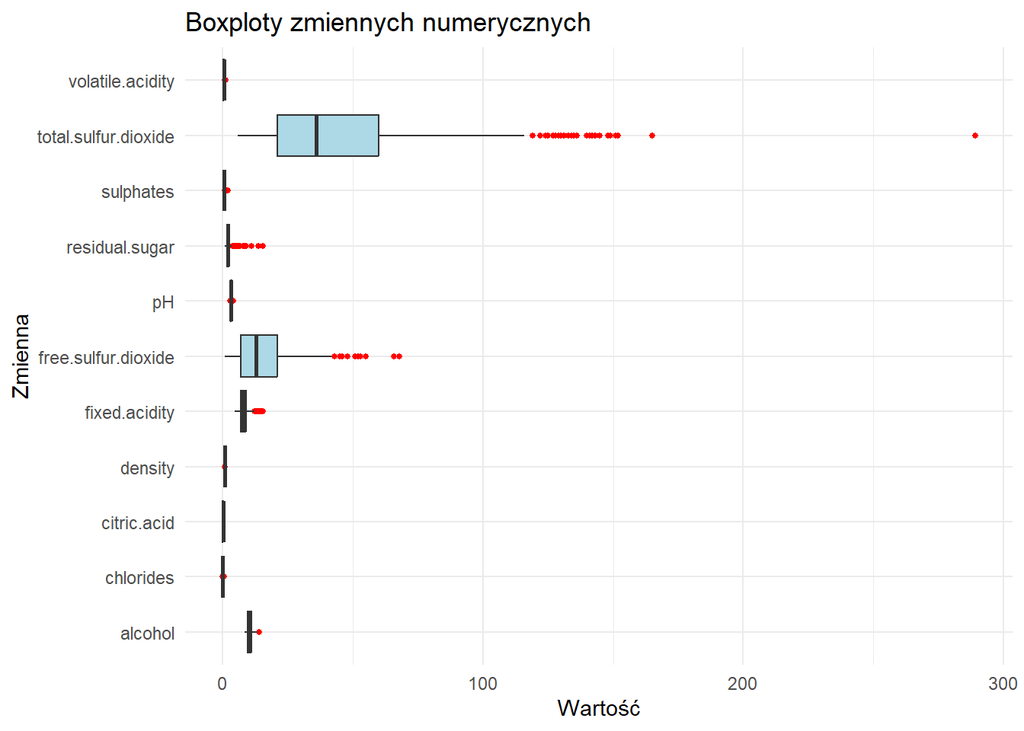

```
                Zmienna Procent_Outliers
1        residual.sugar       0.09103841
2             chlorides       0.08392603
3  total.sulfur.dioxide       0.04267425
4         fixed.acidity       0.03556188
5             sulphates       0.03556188
6               density       0.02987198
7                    pH       0.02133713
8   free.sulfur.dioxide       0.01991465
9      volatile.acidity       0.01137980
10              alcohol       0.00568990
11          citric.acid       0.00000000
```

#### 5.2.2 Transformacja Yeo-Johnson

Niektóre zmienne wykazują znaczną asymetrię oraz obecność wartości odstających, które mogą utrudniać modelowanie, dlatego dla wybranych zmiennych zastosuję transformację Yeo-Johnsona, która:

- Zmniejszy asymetrię rozkładu zmiennych,
- Zredukuje wpływ wartości odstających,
- Ułatwi spełnienie założeń modeli predykcyjnych, szczególnie tych wymagających normalności rozkładu cech (np. regresji liniowej lub logistycznej).

Może być stosowana zarówno do zmiennych przyjmujących wartości dodatnie, jak i ujemne co jest bardzo przydatne do mojego zbioru.

```
# A tibble: 28 × 9
   wflow_id    .config    preproc model .metric .estimator    mean     n std_err
   <chr>       <chr>      <chr>   <chr> <chr>   <chr>        <dbl> <int>   <dbl>
 1 rec_d_lr_lr Preproces… recipe  logi… accura… multiclass 2.13e-2     5 4.49e-3
 2 rec_d_lr_lr Preproces… recipe  logi… f_meas  macro      3.22e-2     5 6.75e-3
 3 rec_d_lr_lr Preproces… recipe  logi… j_index macro      8.78e-4     5 5.76e-4
 4 rec_d_lr_lr Preproces… recipe  logi… kap     multiclass 1.55e-4     5 7.24e-5
 5 rec_dt_dt   Preproces… recipe  deci… accura… multiclass 3.91e-1     5 1.26e-2
 6 rec_dt_dt   Preproces… recipe  deci… f_meas  macro      2.50e-1     5 2.24e-2
 7 rec_dt_dt   Preproces… recipe  deci… j_index macro      1.79e-1     5 4.02e-2
 8 rec_dt_dt   Preproces… recipe  deci… kap     multiclass 1.79e-1     5 1.22e-2
 9 rec_rf_rf   Preproces… recipe  rand… accura… multiclass 5.97e-1     5 1.11e-2
10 rec_rf_rf   Preproces… recipe  rand… f_meas  macro      3.66e-1     5 1.66e-2
# ℹ 18 more rows
```

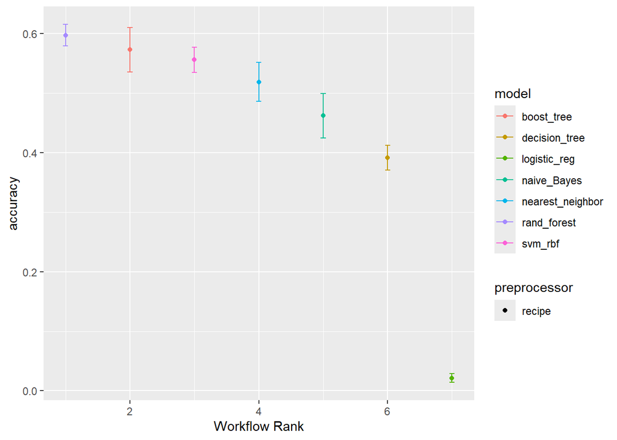

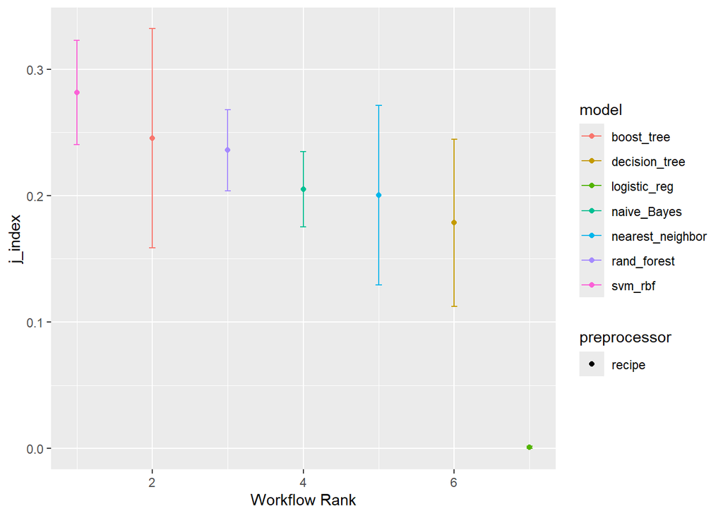

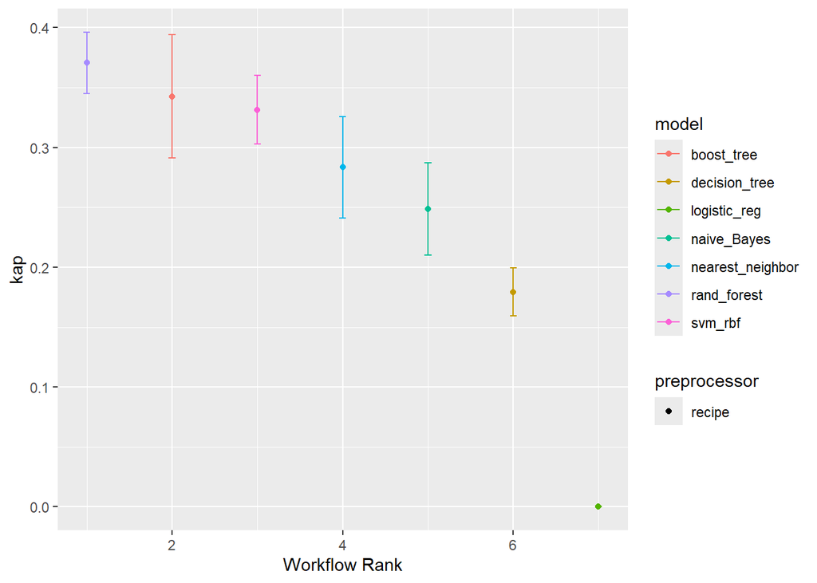

Do tunowania wybiorę 3 modele: las losowy, XGBoost oraz SVM, ponieważ wypadły najlepiej pośród innych modeli.

## 6 Tuning modeli

### 6.1 XGBoost

W metodzie *boosting* odpowiednio modyfikuje się drzewo wyjściowe w kolejnych krokach, ucząc je na tym samym zbiorze treningowym. Uczenie drzew klasyfikacyjnych metodą *boosting* przebiega w sposób podobny do uczenia drzew regresyjnych. Wynik takiego procesu zależy od trzech głównych parametrów:

1. Liczby drzew $B$ - zbyt duża wartość $B$ może prowadzić do przeuczenia modelu. Najczęściej parametr ten ustalany jest na podstawie walidacji krzyżowej.
2. Parametru “kurczenia” $\lambda$ - kontroluje on tempo uczenia się kolejnych drzew. Bardzo małe wartości $\lambda$ mogą wymagać dobrania większego $B$, aby zapewnić dobrą jakość predykcyjną modelu.
3. Liczby podziałów w drzewach $d$, która decyduje o złożoności pojedynczego drzewa.

W pierwszym etapie zdefiniowałam model oraz zestaw jego hiperparametrów przeznaczonych do strojenia - liczba drzew, maksymalna głębokość pojedynczego drzewa decyzyjnego, minimalna liczba obserwacji wymagana do podziału, współczynnik uczenia oraz minimalna redukcja funkcji straty wymagana do wykonania podziału. Następnie model został połączony z wcześniej przygotowanym przepisem.

Kolejnym krokiem było utworzenie siatki hiperparametrów z wykorzystaniem próbkowania hipersześcianu łacińskiego o rozmiarze 5, która jest potrzebna do przeszukiwania w procesie dostrajania.

Na końcu przeprowadziłam proces strojenia modelu (tuning), wykorzystując wcześniej zdefiniowane foldy walidacji krzyżowej, przygotowaną siatkę hiperparametrów oraz wybrane metryki oceny. Proces ten został przyspieszony dzięki zastosowaniu **zrównoleglania**, co pozwoliło na szybsze przeszukiwanie przestrzeni parametrów i skrócenie czasu obliczeń.

```
# A tibble: 20 × 11
   trees min_n tree_depth learn_rate loss_reduction .metric  .estimator  mean
   <int> <int>      <int>      <dbl>          <dbl> <chr>    <chr>      <dbl>
 1  1826     5         10    0.286    0.431         accuracy multiclass 0.589
 2  1826     5         10    0.286    0.431         f_meas   macro      0.402
 3  1826     5         10    0.286    0.431         j_index  macro      0.235
 4  1826     5         10    0.286    0.431         kap      multiclass 0.354
 5   156    10         14    0.0794   0.00000000309 accuracy multiclass 0.563
 6   156    10         14    0.0794   0.00000000309 f_meas   macro      0.357
 7   156    10         14    0.0794   0.00000000309 j_index  macro      0.201
 8   156    10         14    0.0794   0.00000000309 kap      multiclass 0.317
 9   418    18          3    0.00242  0.0000000237  accuracy multiclass 0.408
10   418    18          3    0.00242  0.0000000237  f_meas   macro      0.265
11   418    18          3    0.00242  0.0000000237  j_index  macro      0.193
12   418    18          3    0.00242  0.0000000237  kap      multiclass 0.202
13  1069    29          8    0.00657  0.0000129     accuracy multiclass 0.552
14  1069    29          8    0.00657  0.0000129     f_meas   macro      0.369
15  1069    29          8    0.00657  0.0000129     j_index  macro      0.291
16  1069    29          8    0.00657  0.0000129     kap      multiclass 0.333
17  1562    37          6    0.0174   0.0169        accuracy multiclass 0.553
18  1562    37          6    0.0174   0.0169        f_meas   macro      0.357
19  1562    37          6    0.0174   0.0169        j_index  macro      0.256
20  1562    37          6    0.0174   0.0169        kap      multiclass 0.325
# ℹ 3 more variables: n <int>, std_err <dbl>, .config <chr>
```

```
# A tibble: 5 × 11
  trees min_n tree_depth learn_rate loss_reduction .metric  .estimator  mean
  <int> <int>      <int>      <dbl>          <dbl> <chr>    <chr>      <dbl>
1  1826     5         10    0.286    0.431         accuracy multiclass 0.589
2   156    10         14    0.0794   0.00000000309 accuracy multiclass 0.563
3  1562    37          6    0.0174   0.0169        accuracy multiclass 0.553
4  1069    29          8    0.00657  0.0000129     accuracy multiclass 0.552
5   418    18          3    0.00242  0.0000000237  accuracy multiclass 0.408
# ℹ 3 more variables: n <int>, std_err <dbl>, .config <chr>
```

Po zakończeniu procesu strojenia na siatce hiperparametrów, spośród wszystkich kombinacji wybierany jest najlepszy zestaw parametrów na podstawie wartości metryki **accuracy**. Następnie model jest trenowany ponownie, tym razem na pełnym zbiorze treningowym z wykorzystaniem parametrów dobranych w procesie dostrajania.

Tak przygotowany model wykorzystujemy do określenia predykcji i określenia na tej podstawie metryk.

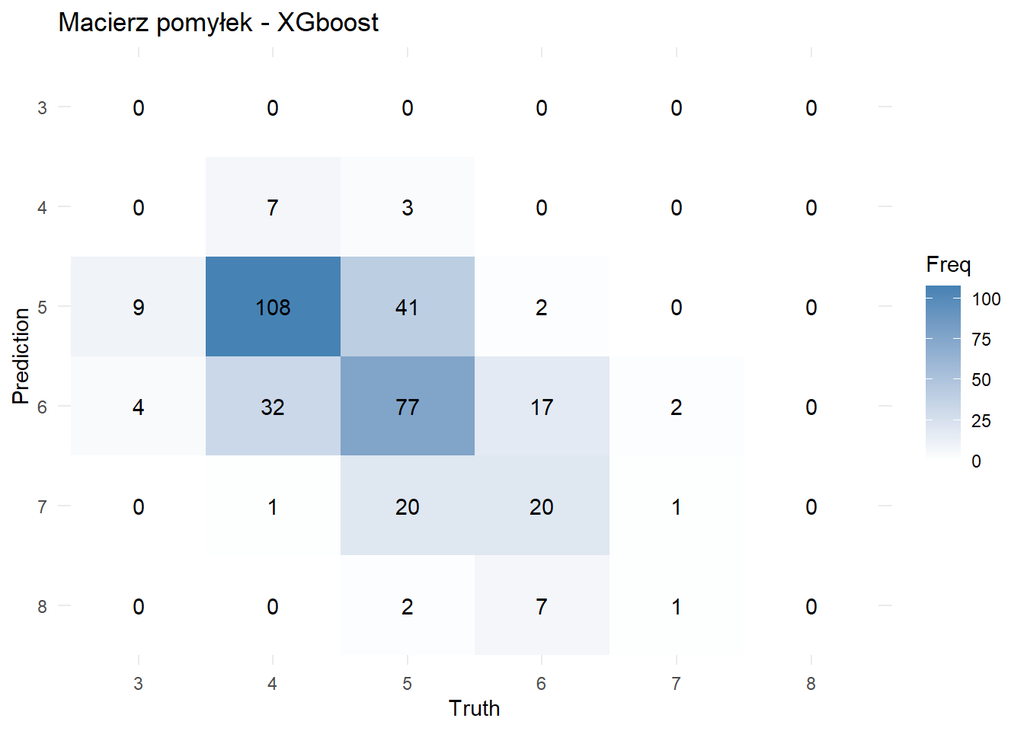

Model najczęściej popełnia błędy klasyfikacyjne w obrębie sąsiadujących klas, co wskazuje na trudność w precyzyjnym rozróżnianiu jakości wina na pograniczu klas. Można zauważyć również tendencje do zawyżania przewidywanych klas, czyli przypisywania wyższej jakości niż w rzeczywistości jest.

Metryki modelu XGboost

| Miara | Wartość |
| --- | --- |
| Dokładność (Accuracy) | 0.186 |
| Statystyka J Youdena | −0.023 |
| F1-score | 0.148 |

Wyniki wskazują, że model XGBoost nie poradził sobie dobrze z zadaniem klasyfikacyjnym. Poprawna klasyfikacja występuje rzadko, ponieważ dokładność (**accuracy**) wynosi 18,6%. **F1-score** wynoszący 0.148 wskazuje na niską równowagę między precyzją a czułością, co potwierdza, że model ma trudności zarówno z identyfikowaniem pozytywnych przypadków, jak i z unikaniem fałszywych alarmów. Ujemna **statystyka J Youdena** (−0.023) oznacza, że model nie wykazuje zdolności do trafnego oddzielania klas, co jest szczególnie niepokojące przy klasyfikacji niezbalansowanej.

### 6.2 Random Forest

**Lasy losowe** stanowią rozszerzenie metody *baggingu*, wzbogacone o dodatkowy element losowości. Podczas konstruowania każdego drzewa wchodzącego w skład lasu, losowo wybiera się $m$ predyktorów spośród wszystkich $p$ dostępnych zmiennych. Budowa drzewa opiera się wyłącznie na tej losowej podpróbie cech. Zazwyczaj wartość $m$ przyjmuje się jako pierwiastek z liczby wszystkich predyktorów, czyli $m = \sqrt{p}$.

Dla tego modelu przeprowadziłam analogiczny proces dostrajania hiperparametrów, tuning, zrównoleglenie oraz ponowne trenowanie.

```
# A tibble: 20 × 9
    mtry trees min_n .metric  .estimator  mean     n std_err .config
   <int> <int> <int> <chr>    <chr>      <dbl> <int>   <dbl> <chr>
 1     4  1214     6 accuracy multiclass 0.592     5 0.0115  Preprocessor1_Mode…
 2     4  1214     6 f_meas   macro      0.361     5 0.0324  Preprocessor1_Mode…
 3     4  1214     6 j_index  macro      0.240     5 0.0352  Preprocessor1_Mode…
 4     4  1214     6 kap      multiclass 0.362     5 0.0174  Preprocessor1_Mode…
 5     9   543    33 accuracy multiclass 0.545     5 0.0113  Preprocessor1_Mode…
 6     9   543    33 f_meas   macro      0.338     5 0.0318  Preprocessor1_Mode…
 7     9   543    33 j_index  macro      0.217     5 0.0381  Preprocessor1_Mode…
 8     9   543    33 kap      multiclass 0.308     5 0.0187  Preprocessor1_Mode…
 9     7  1841    21 accuracy multiclass 0.568     5 0.00894 Preprocessor1_Mode…
10     7  1841    21 f_meas   macro      0.343     5 0.0230  Preprocessor1_Mode…
11     7  1841    21 j_index  macro      0.223     5 0.0280  Preprocessor1_Mode…
12     7  1841    21 kap      multiclass 0.334     5 0.0141  Preprocessor1_Mode…
13    10    45    15 accuracy multiclass 0.549     5 0.00820 Preprocessor1_Mode…
14    10    45    15 f_meas   macro      0.331     5 0.0242  Preprocessor1_Mode…
15    10    45    15 j_index  macro      0.204     5 0.0296  Preprocessor1_Mode…
16    10    45    15 kap      multiclass 0.306     5 0.0135  Preprocessor1_Mode…
17     3  1046    32 accuracy multiclass 0.573     5 0.0135  Preprocessor1_Mode…
18     3  1046    32 f_meas   macro      0.358     5 0.0202  Preprocessor1_Mode…
19     3  1046    32 j_index  macro      0.234     5 0.0241  Preprocessor1_Mode…
20     3  1046    32 kap      multiclass 0.346     5 0.0173  Preprocessor1_Mode…
```

```
# A tibble: 5 × 9
   mtry trees min_n .metric  .estimator  mean     n std_err .config
  <int> <int> <int> <chr>    <chr>      <dbl> <int>   <dbl> <chr>
1     4  1214     6 accuracy multiclass 0.592     5 0.0115  Preprocessor1_Model1
2     3  1046    32 accuracy multiclass 0.573     5 0.0135  Preprocessor1_Model5
3     7  1841    21 accuracy multiclass 0.568     5 0.00894 Preprocessor1_Model3
4    10    45    15 accuracy multiclass 0.549     5 0.00820 Preprocessor1_Model4
5     9   543    33 accuracy multiclass 0.545     5 0.0113  Preprocessor1_Model2
```

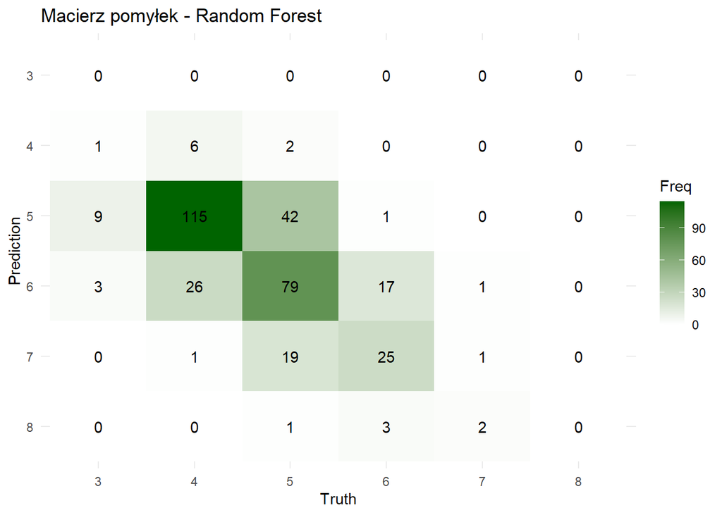

W tym modelu również występuje ta sama sytuacja czyli model najczęściej popełnia błędy klasyfikacyjne “lokalnie” w obrębie sąsiadujących klas oraz zawyżania przewidywane klasy.

Tutaj również największy problem dotyczy klasy 3, która nie jest nigdy przewidywana przez model z tego samego powodu czyli dużego niezbalansowania zmiennej `quality`.

Metryki modelu Random Forest

| Miara | Wartość |
| --- | --- |
| Dokładność (Accuracy) | 0.186 |
| Statystyka J Youdena | −0.027 |
| F1-score | 0.146 |

Podobnie jak w przypadku XGBoost, przyczyną niskiej skuteczności może być **silna nierównowaga klas** oraz obecność klasy niedoreprezentowanej, której model nie jest w stanie skutecznie identyfikować.

### 6.3 SVM

Support Vector Machine (SVM) to metoda klasyfikacyjna, która poszukuje hiperpłaszczyzny maksymalizującej margines oddzielający różne klasy danych. Model stara się znaleźć taką granicę decyzyjną, która maksymalizuje odległość (margines) między najbliższymi punktami należącymi do różnych klas, zwanymi wektorami nośnymi.

Dzięki zastosowaniu funkcji jądra (kernel) SVM może efektywnie radzić sobie z danymi nieliniowo separowalnymi, przekształcając przestrzeń cech do wymiaru wyższego niż oryginalny.

Ważne parametry SVM to:

- Parametr regularizacji $C$ – kontroluje kompromis między maksymalizacją marginesu a minimalizacją błędów klasyfikacji. Wyższe wartości $C$ powodują mniejsze dopuszczenie błędów, ale mogą prowadzić do przeuczenia.
- Wybór funkcji jądra (kernel) – decyduje o sposobie transformacji danych (np. liniowe, wielomianowe, RBF). Odpowiedni dobór kernelu jest kluczowy dla skuteczności modelu.
- Parametry jądra, takie jak współczynnik gamma ($\gamma$) w kernelu RBF, które wpływają na kształt granicy decyzyjnej i zdolność modelu do dopasowania się do danych.

Dla tego modelu przeprowadziłam analogiczny proces dostrajania hiperparametrów, tuning, zrównoleglenie oraz ponowne trenowanie.

```
# A tibble: 20 × 10
       cost degree scale_factor margin .metric  .estimator   mean     n std_err
      <dbl>  <int>        <dbl>  <dbl> <chr>    <chr>       <dbl> <int>   <dbl>
 1  1.12         1     5.57e- 8 0.192  accuracy multiclass 0.0981     5 0.0151
 2  1.12         1     5.57e- 8 0.192  f_meas   macro      0.119      5 0.0159
 3  1.12         1     5.57e- 8 0.192  j_index  macro      0.166      5 0.0489
 4  1.12         1     5.57e- 8 0.192  kap      multiclass 0.0486     5 0.0125
 5  0.0253       3     1.55e-10 0.157  accuracy multiclass 0.137      5 0.0328
 6  0.0253       3     1.55e-10 0.157  f_meas   macro      0.131      5 0.0261
 7  0.0253       3     1.55e-10 0.157  j_index  macro      0.233      5 0.0517
 8  0.0253       3     1.55e-10 0.157  kap      multiclass 0.0604     5 0.0261
 9 16.2          2     2.26e- 4 0.105  accuracy multiclass 0.415      5 0.0156
10 16.2          2     2.26e- 4 0.105  f_meas   macro      0.296      5 0.0206
11 16.2          2     2.26e- 4 0.105  j_index  macro      0.302      5 0.0262
12 16.2          2     2.26e- 4 0.105  kap      multiclass 0.225      5 0.0164
13  0.00107      1     8.87e- 6 0.0307 accuracy multiclass 0.0953     5 0.0161
14  0.00107      1     8.87e- 6 0.0307 f_meas   macro      0.118      5 0.0168
15  0.00107      1     8.87e- 6 0.0307 j_index  macro      0.194      5 0.0605
16  0.00107      1     8.87e- 6 0.0307 kap      multiclass 0.0467     5 0.0134
17  0.409        2     6.82e- 2 0.0593 accuracy multiclass 0.502      5 0.0190
18  0.409        2     6.82e- 2 0.0593 f_meas   macro      0.331      5 0.0165
19  0.409        2     6.82e- 2 0.0593 j_index  macro      0.253      5 0.00677
20  0.409        2     6.82e- 2 0.0593 kap      multiclass 0.279      5 0.0224
# ℹ 1 more variable: .config <chr>
```

```
# A tibble: 5 × 10
      cost degree scale_factor margin .metric  .estimator   mean     n std_err
     <dbl>  <int>        <dbl>  <dbl> <chr>    <chr>       <dbl> <int>   <dbl>
1  0.409        2     6.82e- 2 0.0593 accuracy multiclass 0.502      5  0.0190
2 16.2          2     2.26e- 4 0.105  accuracy multiclass 0.415      5  0.0156
3  0.0253       3     1.55e-10 0.157  accuracy multiclass 0.137      5  0.0328
4  1.12         1     5.57e- 8 0.192  accuracy multiclass 0.0981     5  0.0151
5  0.00107      1     8.87e- 6 0.0307 accuracy multiclass 0.0953     5  0.0161
# ℹ 1 more variable: .config <chr>
```

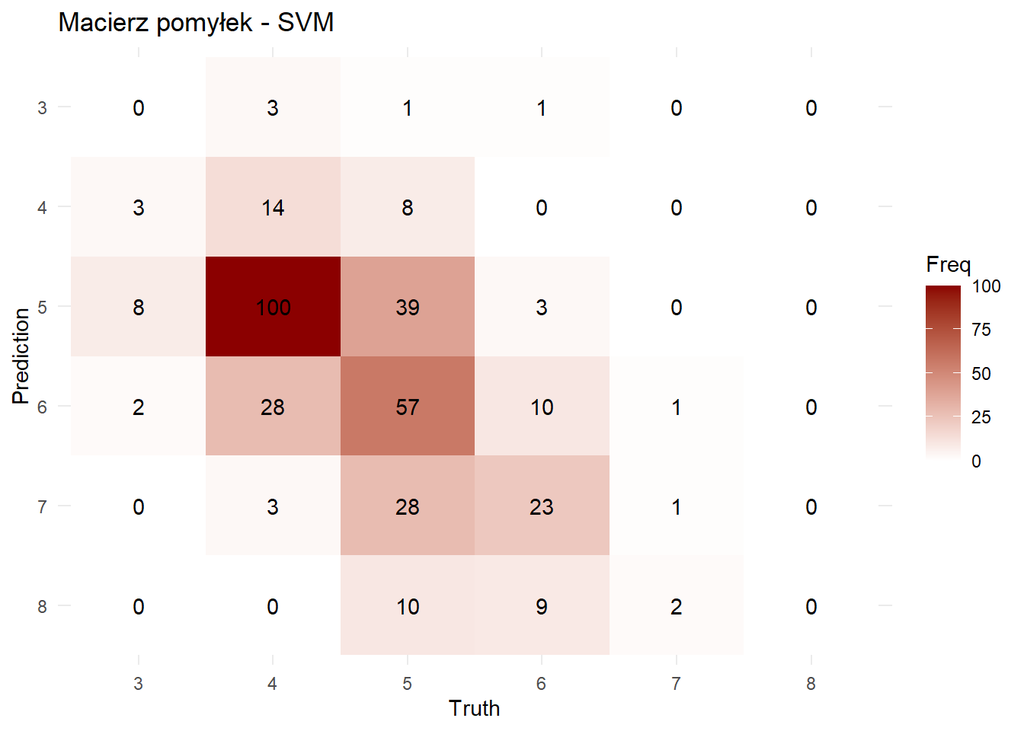

W tym modelu również występuje ta sama sytuacja czyli model najczęściej popełnia błędy klasyfikacyjne “lokalnie” w obrębie sąsiadujących klas oraz zawyżania przewidywane klasy.

Tutaj również największy problem dotyczy klasy jakościowo najgorszej, jednakże ten model poradził sobie z nią najlepiej i w niektórych przypadkach przewidywał klasę 3. Również wynika to z tego samego powodu czyli dużego niezbalansowania zmiennej `quality`, aczkolwiek pod tym względem SVM góruje nad XGBoostem i lasem losowym, bo “zauważa” klasę 3.

Metryki modelu SVM

| Miara | Wartość |
| --- | --- |
| Dokładność (Accuracy) | 0.181 |
| Statystyka J Youdena | −0.040 |
| F1-score | 0.120 |

Wyniki modelu SVM wskazują na niską skuteczność w analizowanym zadaniu klasyfikacyjnym. Dokładność na poziomie 18,1% oznacza, że poprawne przewidywania występują rzadko i są zbliżone do losowych, co jest szczególnie niekorzystne w kontekście wieloklasowego i niezrównoważonego zbioru danych. F1-score wynoszący 0.120 potwierdza, że model ma trudności z utrzymaniem równowagi między precyzją a czułością – nie tylko nie rozpoznaje efektywnie przypadków należących do klas mniejszościowych, ale też generuje wiele błędnych klasyfikacji. Ujemna wartość statystyki J Youdena (−0.040) dodatkowo wskazuje, że model nie wykazuje zdolności do skutecznego rozróżniania klas, co może być efektem nierównomiernego rozkładu danych oraz ograniczeń wynikających z doboru parametrów jądra i regularyzacji. Rezultaty te sugerują, że mimo teoretycznych zalet SVM, w obecnym kontekście model nie był w stanie dostosować się do charakterystyki problemu.

## 7 Porównanie modeli

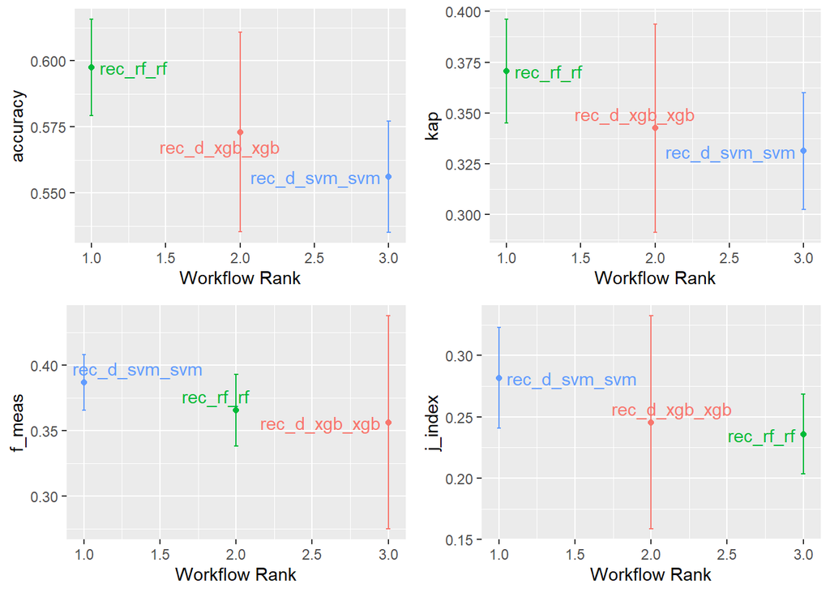

**Random Forest (las losowy)** oraz **Boosted Tree (XGBoost)** okazują się najlepiej radzącymi sobie modelami w zadaniu klasyfikacyjnym. Spośród wszystkich testowanych algorytmów osiągają najwyższe wyniki w kluczowych metrykach, takich jak Accuracy oraz Kap. To właśnie te modele najlepiej radzą sobie z różnorodnością cech i są odporne na przeuczenie.

Z kolei SVM, mimo że charakteryzuje się wyższym F1 Score oraz J. Youdenem, to trochę odstaje od pozostałych modeli pod względem pozostałych miar skuteczności, co ogranicza jego przydatność w praktyce. SVM ma problem z np. nierównomiernym rozkładem klas i specyficzną charakterystyką danych., ale jest skuteczny w balansowaniu precyzji i recall, oraz ma lepszą zdolność do odróżniania klas (Youden to miara czułości i specyficzności).

### 7.1 Krzywa ROC

W trakcie analizy modelu klasyfikacyjnego napotkałam trudności z wygenerowaniem krzywej ROC oraz obliczeniem wartości AUC ze względu na specyfikę problemu i strukturę danych. Zmienna docelowa posiada wiele klas (6 klas). Standardowa funkcja `roc_curve()` z pakietu `yardstick` jest przystosowana do zadań binarnej klasyfikacji.

W efekcie, z powodu wieloklasowości problemu, niezbalansowania klas oraz wymagań co do formatu danych, nie udało się bezpośrednio wygenerować krzywych ROC i wartości AUC. Do oceny jakości modeli wykorzystałam zatem inne metryki, takie jak Accuracy, Kap, F1 Score oraz statystykę Youdena, które lepiej odpowiadają charakterystyce problemu wieloklasowego.

Porównanie modeli klasyfikacyjnych

| Model | Accuracy | F1_Score | J_index | Kap |
| --- | --- | --- | --- | --- |
| Regresja logistyczna | 0.021 | 0.032 | 0.001 | 0.000 |
| Decision Tree | 0.391 | 0.250 | 0.179 | 0.179 |
| Random Forest | 0.597 | 0.366 | 0.236 | 0.371 |
| Naive Bayes | 0.462 | 0.321 | 0.205 | 0.249 |
| XGBoost | 0.573 | 0.356 | 0.245 | 0.343 |
| SVM | 0.556 | 0.387 | 0.282 | 0.331 |
| KNN | 0.519 | 0.326 | 0.200 | 0.284 |

Natomiast **SVM** wyróżnia się wyższym wynikiem F1 Score oraz J_index, co sugeruje, że lepiej radzi sobie z kompromisem między precyzją a czułością, mimo nieco niższej dokładności niż Random Forest.

## 8 Podsumowanie

Celem projektu było stworzenie modelu klasyfikacyjnego przewidującego jakość wina na podstawie dostępnych danych chemicznych i sensorycznych.

Dane zostały dokładnie przygotowane, a ocena modeli została przeprowadzona za pomocą 5-krotnej walidacji krzyżowej ze stratyfikacją.

Przetestowano różne algorytmy klasyfikacyjne, w tym regresję logistyczną, drzewo decyzyjne, las losowy, Naive Bayes, SVM oraz XGBoost.

Najlepsze wyniki uzyskał las losowy (Random Forest), który osiągnął najwyższą dokładność oraz zrównoważone wartości metryk takich jak F1 Score, indeks J oraz statystyka Kap.

Wyniki pokazują, że zastosowanie metod, takich jak las losowy czy XGBoost, istotnie poprawia jakość przewidywań w porównaniu do prostszych modeli.

## 9 **Bibliografia**

- https://dax44.github.io/EksploracjaDanych/index.html
- https://dax44.github.io/ModelsValidation/comparison.html
- https://pl.wikipedia.org/wiki/Wikipedia:Strona_g%C5%82%C3%B3wna
- https://topepo.github.io/caret/available-models.html
- Wiedza teoretyczna i praktyczna zdobyta podczas wykładów i laboratoriów z przedmiotu *Metody walidacji modeli statystycznych.*